# Julia

[figure not shown]

Eficiencia computacional

David Gómez-Castro

May 1, 2026

# Álgebra Lineal

## Usa tipos de matrices

```julia
N = 1000
A = zeros(N,N)
for i=1:N
  for j=1:N
    A[i,j] = rand()
  end
end

x = rand(N)
@btime A * x;
```

```
  266.768 μs (3 allocations: 7.88 KiB)
```

```julia
using LinearAlgebra
B = UpperTriangular(A)
@btime B*x;
```

```
  150.793 μs (3 allocations: 7.88 KiB)
```

## Paquetes con tipos adicionales

```julia
using BenchmarkTools
N = 10_000
A = zeros(N,N)
for i=1:N
  A[i,i] = 1.
  A[i,[1:i-1;i+1:N]] .= -1 / (3*N)
end
x = rand(N)
@btime A*x;
```

```
  32.077 ms (3 allocations: 78.20 KiB)
```

```julia
using ToeplitzMatrices #usa FFT para matrices banda

vc = [ 1.;  -ones(N-1) / (3*N) ]
B = SymmetricToeplitz(vc)
@btime B*x;
```

```
  286.165 μs (17 allocations: 1016.19 KiB)
```

## *si resuelves muchas veces, factoriza tus matrices*

```julia
using BenchmarkTools

N = 100
A = rand(N,N)
b = ones(N)

@btime A \ b ;
```

```
  59.081 μs (7 allocations: 80.02 KiB)
```

```julia
using LinearAlgebra

print("Factorizar:")
@btime factorize(A)
B = factorize(A)
print("Resolver:")
@btime B \ b
@show typeof(B);
```

```
Factorizar:  52.552 μs (6 allocations: 79.15 KiB)
Resolver:  4.239 μs (2 allocations: 928 bytes)
typeof(B) = LinearAlgebra.LU{Float64, Matrix{Float64}, Vector{Int64}}
```

[Documentación](https://deepwiki.com/JuliaLang/LinearAlgebra.jl/4-matrix-factorizations)

## Para vectores pequeños y cuyos valores no cambian usa `static array`

[`StaticArrays.jl`](https://github.com/JuliaArrays/StaticArrays.jl)

```julia
using StaticArrays, BenchmarkTools

A = [1 2 3; 4 5 6; 7 8 9]
B = @SMatrix [1 2 3; 4 5 6; 7 8 9]

@btime A^20
@btime B^20;
```

```
  390.820 ns (10 allocations: 720 bytes)
  73.917 ns (1 allocation: 80 bytes)
```

```julia
B[3,3] = 1
```

```
setindex!(::StaticArraysCore.SMatrix{3, 3, Int64, 9}, value, ::Int) is not defined.
 Hint: Use `MArray` or `SizedArray` to create a mutable static array
Stacktrace:
 [1] error(s::String)
   @ Base ./error.jl:44
 [2] setindex!(a::SMatrix{3, 3, Int64, 9}, value::Int64, i::Int64)
   @ StaticArrays ~/.julia/packages/StaticArrays/0cEwi/src/indexing.jl:3
 [3] macro expansion
   @ ~/.julia/packages/StaticArrays/0cEwi/src/indexing.jl:66 [inlined]
 [4] _setindex!_scalar
   @ ~/.julia/packages/StaticArrays/0cEwi/src/indexing.jl:46 [inlined]
 [5] setindex!(::SMatrix{3, 3, Int64, 9}, ::Int64, ::Int64, ::Int64)
   @ StaticArrays ~/.julia/packages/StaticArrays/0cEwi/src/indexing.jl:42
 [6] top-level scope
   @ ~/Github/curso-intro-julia/src/03-Eficiencia.qmd:108
```

# Cálculo paralelo

En este curso no haremos hincapié en las capacidades y técnicas de Julia para hacer cálculo en paralelo.

Los paralelización básica puede hacerse con [`Base.Threads`](https://docs.julialang.org/en/v1/manual/multi-threading/)

Para el cálculo paralelo distribuido se cuenta con `Distributed` en la Standard Library. Véase este [Tutorial](https://docs.julialang.org/en/v1/manual/distributed-computing/).

Para cálculo paralelo en GPU hay un conjunto de paquetes llamados JuliaGPU: [Cuda.jl](https://cuda.juliagpu.org/stable/), AMDGPU.jl, Metal.jl, OpenCL.jl, …

## Threads

```julia
@show Threads.nthreads()
```

```
Threads.nthreads() = 10
```

```
10
```

```bash
julia --threads 4
```

En Linux/MacOS podemos fijar el número de threads en .bashrc/.zshrc fijando

```bash
export JULIA_NUM_THREADS=4
```

Hecho esto podemos ejecutar bucles en paralelo

```julia
using Base.Threads
N = 20
a = Vector{Float64}(undef, N)
@threads for i=1:N
  a[i] = i^2
end
```

Hay que tener cuidado con los cálculos inseguros. Si tenemos más de un thread activo el siguiente código dará resultados inesperados:

```julia
using Base.Threads
N = 1000
@show sum([ i for i = 1:N ])

s = 0
@threads for i=1:N
  global s += i
end
@show s;
```

[output not shown]

## [Distributed](https://github.com/JuliaLang/Distributed.jl)

# Uso de GPUs

```julia
using CUDA, BenchmarkTools
N = 10_000
A = rand(N, N);
B = CuArray(A);

@btime A * A; # 1.875 s (3 allocations: 762.94 MiB)

@time B * B; #  0.686287 seconds (1.75 M allocations: 87.821 MiB, 93.91% compilation time)
@time B * B; # 0.000114 seconds (55 allocations: 1.250 KiB
```

# [Memoization](https://github.com/JuliaCollections/Memoize.jl)

Permite que funciones costosas no se recalculen en el mismo punto

```julia
using Memoize
@memoize function mifuncion(a)
    println("Running")
    sleep(3)
    return 2a
end
```

```
mifuncion (generic function with 1 method)
```

```julia
@time mifuncion(1)
```

```
Running
  3.004192 seconds (22 allocations: 120.875 KiB)
```

```
2
```

```julia
@time mifuncion(1)
```

```
  0.000003 seconds
```

```
2
```

```julia
memoize_cache(mifuncion)
```

```
IdDict{Any, Any} with 1 entry:
  (1,) => 2
```

# Reserva de memoria - Ejemplo en el conjunto de Cantor

## Conjunto de Cantor

Si representamos el segmento $(a,b)$ por la tupla `(a,b)`, una iteración del cojunto de Cantor es un vector de tuplas. Una implementación posible es

```julia
function CantorIter(cantor)
    N = length(cantor)
    new_cantor = Array{Tuple{Float64,Float64}}(undef, 2 * N)

    for i = 1:N
        (a₁, a₂) = cantor[i]
        b₁ = (2 * a₁ + a₂) / 3
        b₂ = (a₁ + 2 * a₂) / 3

        new_cantor[2*i-1] = (a₁, b₁)
        new_cantor[2*i] = (b₂, a₂)
    end
    return new_cantor
end;
```

## Representando el conjunto de datos

```julia
using Plots
function plotCantor(cantor::Array, n::Integer)
    p = plot(
        title="Conjunto de Cantor n = $n",
        xticks=([0, 1]), yticks=[],
        ylim=(-1, 1))
    for j = 1:length(cantor)
        p = plot!(
            [first(cantor[j]), last(cantor[j])],
            [0, 0],
            linewidth=2,
            axis=([], false),
            color=:black,
            label="")
    end
    return p
end;
```

Para representar $n$ pasos, aplicamos la fórmula iterativa

```
[ Info: Saved animation to /tmp/jl_KJAl8XQLOv.gif
```

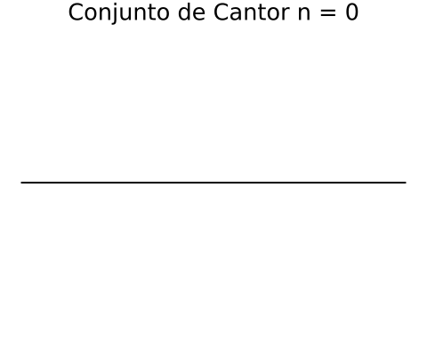

```julia
cantor = [(0, 1)]
@gif for n = 0:5
    plotCantor(cantor, n)
    global cantor = CantorIter(cantor)
end fps = 1
```

## Implementación recursiva

La siguiente implementación recursiva devuelve directamente el paso $n$-ésimo

```julia
function CantorRec(a₁::Real, a₂::Real, n::Integer)
    if n > 0
        b₁ = (2 * a₁ + a₂) / 3
        b₂ = (a₁ + 2 * a₂) / 3
        return [CantorRec(a₁, b₁, n - 1); CantorRec(b₂, a₂, n - 1)]
    else
        return [(a₁, a₂)]
    end
end;
```

Comprobamos el timpo de computación

```julia
N = 25
@show N
println("Recursivo")
@time CantorRec(0.0, 1.0, N)
@time cantorRec = CantorRec(0.0, 1.0, N)
println("---")
println("Iterativo")
for i = 1:2
    @time begin
        global cantorIter = [(0, 1)]
        for n = 1:N
            cantorIter = CantorIter(cantorIter)
        end
    end
end

@show isequal(cantorRec, cantorIter);
```

```
N = 25
Recursivo
  7.175458 seconds (134.77 M allocations: 17.021 GiB, 28.98% gc time, 0.26% compilation time)
  6.218460 seconds (134.74 M allocations: 17.020 GiB, 22.38% gc time)
---
Iterativo
  0.863234 seconds (112 allocations: 1.000 GiB, 23.05% gc time)
  0.685590 seconds (106 allocations: 1.000 GiB, 15.82% gc time)
isequal(cantorRec, cantorIter) = true
```

## Utilizando `@view`

En `julia` los vectores se pasan a la funciones por *sharing*, lo que ahorra memoria.

Sin embargo, si pasamos un rango de un vector (por ejemplo `v[2:3]`) entonces se pasa una copia. Para que se pasa por *sharing*, y poder cambiarlo, se puede utilizar el macro `@view`.

```julia
function CantorRecAllocated!(a₁::Real, a₂::Real, cantor)
    if length(cantor) == 1
        cantor[1] = (a₁, a₂)
    else
        L = div(length(cantor), 2)
        b₁ = (2 * a₁ + a₂) / 3
        b₂ = (a₁ + 2 * a₂) / 3
        CantorRecAllocated!(a₁, b₁, @view cantor[1:L])
        CantorRecAllocated!(b₂, a₂, @view cantor[L+1:end])
    end
end;
```

## Eficiencia computacional

```julia
println("Recursivo con reserva de memoria prueba 1")
print("Reserva de memoria = ")
@time cantorRecAllocated = Vector{Tuple{Float64,Float64}}(undef, 2^N)
print("Cálculo de los valores = ")
@time CantorRecAllocated!(0.0, 1.0, cantorRecAllocated)
println("----")
println("Recursivo con reserva de memoria prueba 2")
print("Reserva de memoria = ")
@time cantorRecAllocated2 = Vector{Tuple{Float64,Float64}}(undef, 2^N)
print("Cálculo de los valores = ")
@time CantorRecAllocated!(0.0, 1.0, cantorRecAllocated2)

@show isequal(cantorRecAllocated, cantorIter);
```

```
Recursivo con reserva de memoria prueba 1
Reserva de memoria =   0.044784 seconds (98 allocations: 512.009 MiB, 86.68% gc time, 13.03% compilation time)
Cálculo de los valores =   0.562069 seconds (93.55 k allocations: 4.392 MiB, 3.84% compilation time)
----
Recursivo con reserva de memoria prueba 2
Reserva de memoria =   0.067756 seconds (16 allocations: 512.004 MiB, 99.78% gc time)
Cálculo de los valores =   1.069342 seconds (1 allocation: 32 bytes)
isequal(cantorRecAllocated, cantorIter) = true
```

# Iteradores

## Generadores

Recordamos que en `julia` podemos utilizar *list comprehension*

```julia
[i for i=1:5]
```

```
5-element Vector{Int64}:
 1
 2
 3
 4
 5
```

esto es útil, por ejemplo, dentro de `sum`.

Pensando qué hace `sum`, realmente no necesitamos ocupar todo el espacio de memoria y podemos hacer evaluación `lazy`. Para esto `julia` *generadores*. En términos de sintaxis basta con decir

```julia
sum((i for i=1:5))
```

```
15
```

¿Qué objeto es este?

```julia
gen = (i for i=1:5)
```

```
Base.Generator{UnitRange{Int64}, typeof(identity)}(identity, 1:5)
```

Podemos convertirlo en vector

```julia
collect(gen)
```

```
5-element Vector{Int64}:
 1
 2
 3
 4
 5
```

El uso de generadores viene con enormes ganancias en rendimiento

```julia
using BenchmarkTools
N = 1_000_000
@btime sum([i for i=1:N])
@btime sum((i for i=1:N))
```

```
  716.098 μs (6 allocations: 7.63 MiB)
  120.682 ns (3 allocations: 80 bytes)
```

```
500000500000
```

Los generadores son un tipo de `iterator`

## Iterators

Un `iterator` es una estructura`struct` y una implementación de

| Required method | Brief description |
| --- | --- |
| `iterate(iter)` | Returns either a tuple of the first item and initial state or nothing if empty |
| `iterate(iter, state)` | Returns either a tuple of the next item and next state or nothing if no items remain |

El código

```julia
for item in iter   # or  "for item = iter"
    # body
end
```

se traduce por

```julia
next = iterate(iter)
while next !== nothing
    (item, state) = next
    # body
    next = iterate(iter, state)
end
```

## Ejemplo

Pongamos que queremos calcular $\sum_{n=0}^N n^2$ de manera eficiente. Podemos generar un iterador que genere $r^n$ iterativamente

```julia
mutable struct Cuadrados
  # calcularemos cuadrados hasta que n > count
  count::Int
end

# caso base
function Base.iterate(S::Cuadrados)
  n = 1
  return n^2, n+1 # (resultado, siguiente estado)
end

# iteracion
function Base.iterate(S::Cuadrados, state)
  if state > S.count
    return nothing
  else
    n = state
    return (n^2, n+1)
  end
end
```

```julia
N = 5
for m in Cuadrados(N)
  print(m, " ")
end
```

```
1 4 9 16 25
```

Esto está ya implementado

```julia
S = Cuadrados(6)
25 in S
```

```
true
```

Podemos simplicar el constructor, especificando el caso base como parámetro con valor por defecto

```julia
mutable struct Cuadrados
  count::Int # último número
end

function Base.iterate(S::Cuadrados, state=1)
  if state > S.count
    return nothing
  else
    n = state
    return (n^2, n+1)
  end
end
```

Se puede usar la implementación genérica

```julia
@show sum(S)
```

```
sum(S) = 91
```

```
91
```

, pero a veces es interesante dar valores precisos aprovechando fórmulas cerradas

```julia
function Base.sum(S::Cuadrados)
  n = S.count
  return n*(n+1)*(2n+1)÷6
end
```

Hay que tener cuidado con algunas cuestiones. Por ejemplo

```julia
[i for i in Cuadrados(5)]
```

```
MethodError: no method matching length(::Cuadrados)
The function `length` exists, but no method is defined for this combination of argument types.
You may need to implement the `length` method or define `IteratorSize` for this type to be `SizeUnknown`.

Closest candidates are:
  length(::Markdown.MD)
   @ Markdown ~/.julia/juliaup/julia-1.12.5+0.x64.linux.gnu/share/julia/stdlib/v1.12/Markdown/src/parse/parse.jl:35
  length(::DataStructures.SparseIntSet)
   @ DataStructures ~/.julia/packages/DataStructures/qUuAY/src/sparse_int_set.jl:61
  length(::DataStructures.EnumerateAll)
   @ DataStructures ~/.julia/packages/DataStructures/qUuAY/src/multi_dict.jl:96
  ...

Stacktrace:
 [1] length(g::Base.Generator{Cuadrados, typeof(identity)})
   @ Base ./generator.jl:51
 [2] _similar_shape(itr::Base.Generator{Cuadrados, typeof(identity)}, ::Base.HasLength)
   @ Base ./array.jl:657
 [3] collect(itr::Base.Generator{Cuadrados, typeof(identity)})
   @ Base ./array.jl:789
 [4] top-level scope
   @ ~/Github/curso-intro-julia/src/03-Eficiencia/iterators.qmd:157
```

Falla porque `julia` quiere reservar el espacio de memoria antes de llenarlo, y necesita saber `length`

```julia
Base.length(S::Cuadrados) = S.count
```

ya podemos

```julia
[i for i in Cuadrados(5)]
```

```
5-element Vector{Int64}:
  1
  4
  9
 16
 25
```

También podemos fijar

```julia
Base.eltype(S::Type{Cuadrados}) = Int64
```

## Ganancia computacional

```julia
N = 100_000_000
@btime sum([i^2 for i = 1:N])
@btime sum((i^2 for i = 1:N))
@btime sum(Cuadrados(N));
```

```
  283.405 ms (6 allocations: 762.94 MiB)
  252.586 ns (3 allocations: 80 bytes)
  3.060 ns (0 allocations: 0 bytes)
```